# Data Analytics Project Report - Text mining

Louis, Floriann Deepika

December - 2021`

# 1 Text Mining

## 1.1 The dataset GoodReads.csv contains book descriptions. Load this dataset and draw random sample of size 5000 from it, setting the seed to 31.

```r
#Text Extraction
data_main <-read.csv("GoodReads.csv", header=T, stringsAsFactors = TRUE)
#Drawing random sample of size 5000
set.seed(31)
data_goodread <- data_main[sample(nrow(data_main), 5000), ]
```

## 1.2 Plot and describe the distribution of average ratings of the books.

```r
#Mean of rating:
mean (data_goodread$rating)
```

```
## [1] 3.828692
```

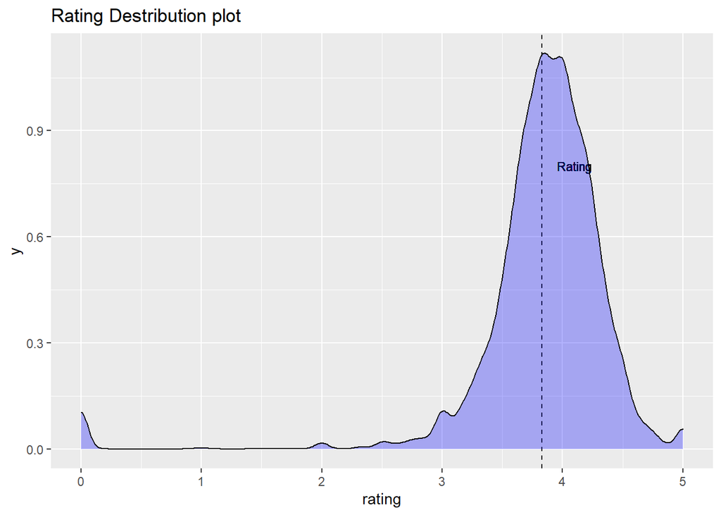

```r
#Plotting the rating distribution
ggplot(data_goodread,aes(x=rating)) +
  geom_text(aes(x=4.1, y=.8, label='Rating'), size=3)+
  geom_vline(aes(xintercept=mean(rating)), linetype='dashed')+
  geom_density(alpha= 0.3,fill='blue')+
  ggtitle('Rating Destribution plot')
```

Average value of feature rating is 3.828692. From the distribution graph we can observe that the data points are left skewed, which means most of the value lie between 3 and 5.

## 1.3 Clean the data in your dataframe. Explain your reasoninng for selecting the cleaning methods you decided to use.

```r
#Analysing the structure of the dataset:
data_goodread %>% glimpse()
```

```
## Rows: 5,000
## Columns: 13
## $ ï..author    <fct> "Milton Rokeach", "Bennett Cerf", "Gyorgy Scrinis", "Albe~
## $ bookformat   <fct> "Paperback", "", "Hardcover", "Paperback", "Paperback", "~
## $ desc         <fct> "On July 1, 1959, at Ypsilanti State Hospital in Michigan~
## $ genre        <fct> "Psychology,Nonfiction,Science,Health,Mental Health,Philo~
## $ img          <fct> https://i.gr-assets.com/images/S/compressed.photo.goodrea~
## $ isbn         <fct> 231052715, , 231156561, 080913022X, 1846687756, 425250997~
## $ isbn13       <fct> 9.78023E+12, , 9.78023E+12, 9.78E+12, 9.78E+12, 9.78E+12,~
## $ link         <fct> https://goodreads.com/book/show/1401403.The_Three_Christs~
## $ pages        <int> 338, 0, 352, 672, 343, 277, 470, 288, 385, 764, 222, 338,~
## $ rating       <dbl> 3.76, 3.25, 3.84, 3.92, 3.68, 4.08, 4.11, 3.63, 4.05, 3.9~
## $ reviews      <int> 108, 0, 11, 3, 1747, 23, 2, 3, 2033, 141, 4, 324, 218, 27~
## $ title        <fct> "The Three Christs of Ypsilanti: A Psychological Study", ~
## $ totalratings <int> 819, 4, 51, 12, 15465, 464, 36, 24, 20666, 2955, 110, 516~
```

```r
#Selecting only relevant Values
data_goodread <- data_goodread %>% select(c(desc,rating))
```

Only relevant features desc and rating is selected for further text analysis.

```r
#Check NA values
apply(is.na(data_goodread),2, sum)
```

```
##   desc rating
##      0      0
```

From the above table we can see that there are no Null values.

## 1.4 Categorize the rating variable into several categories. Explain how many categories you decided to have, where you drew the line, and why you decided to do it this way

```r
data_goodread <- mutate (data_goodread
                          , rating_category = case_when(
                                              data_goodread$rating > 0 & data_goodread$rating <= 1 ~ 1
                                            , data_goodread$rating > 1 & data_goodread$rating <= 2 ~ 2
                                            , data_goodread$rating > 2 & data_goodread$rating <= 3 ~ 3
                                            , data_goodread$rating > 3 & data_goodread$rating <= 4 ~ 4
                                            , data_goodread$rating > 4 ~ 5))

rating_grouped <- prop.table(table(data_goodread$rating_category))
rating_grouped <- as.data.frame(rating_grouped)
rating_grouped
```

| Var1 | Freq |
| --- | --- |
| 1 | 0.0004061738 |
| 2 | 0.0028432169 |
| 3 | 0.0251827782 |
| 4 | 0.5946385053 |
| 5 | 0.3769293258 |

Considering the rating value which lies from 0 to 5. I have categorized the observations in to 5 category as 1,2,3,4,5. Each category is assigned under standard specific range.

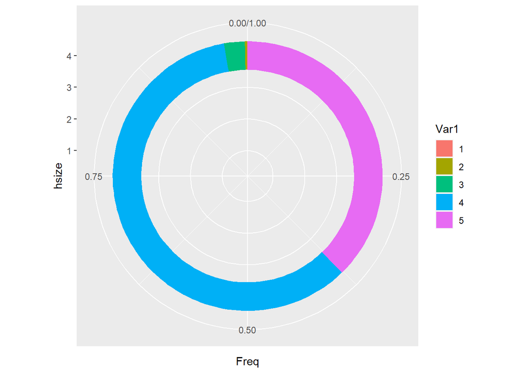

```r
hsize <- 4
rating_grouped_pie <- rating_grouped %>% mutate(x = hsize)
ggplot(rating_grouped_pie, aes(x = hsize, y = Freq, fill = Var1)) +
  geom_col() +
  coord_polar(theta = "y") +
  xlim(c(0.2, hsize + 0.5))
```

This graph shows how the rating is distributed.

## 1.5 Get a feel about the distribution of text lengths of the book descriptions by adding a new feature for the length of each message. Check the statistical values.

```r
#Creating a new feature named desc_len
data_goodread$desc_len <- str_count(data_goodread$desc)
```

```r
#statistical values of the variable
skim(data_goodread)
```

Data summary

| Name | data_goodread |
| --- | --- |
| Number of rows | 5000 |
| Number of columns | 4 |
| _______________________ |  |
| Column type frequency: |  |
| factor | 1 |
| numeric | 3 |
| ________________________ |  |
| Group variables | None |

**Variable type: factor**

| skim_variable | n_missing | complete_rate | ordered | n_unique | top_counts |
| --- | --- | --- | --- | --- | --- |
| desc | 0 | 1 | FALSE | 4653 | emp: 338, Man: 3, Thi: 3, Thi: 3 |

**Variable type: numeric**

| skim_variable | n_missing | complete_rate | mean | sd | p0 | p25 | p50 | p75 | p100 | hist |
| --- | --- | --- | --- | --- | --- | --- | --- | --- | --- | --- |
| rating | 0 | 1.00 | 3.83 | 0.62 | 0 | 3.66 | 3.9 | 4.13 | 5 | ▁▁▁▇▅ |
| rating_category | 76 | 0.98 | 4.34 | 0.55 | 1 | 4.00 | 4.0 | 5.00 | 5 | ▁▁▁▇▅ |
| desc_len | 0 | 1.00 | 849.29 | 781.17 | 0 | 404.00 | 757.0 | 1134.25 | 27459 | ▇▁▁▁▁ |

The dataset consist of 5000 observations and 4 features. There are two column types. Namely, factor and numeric. The distribution of the variables are skewed, where rating and rating category exhibits left skewness and desc_len shows right skewness.

## 1.6 Visualize the distribution of text lengths with a histogram, where the colouring is according to the rating category

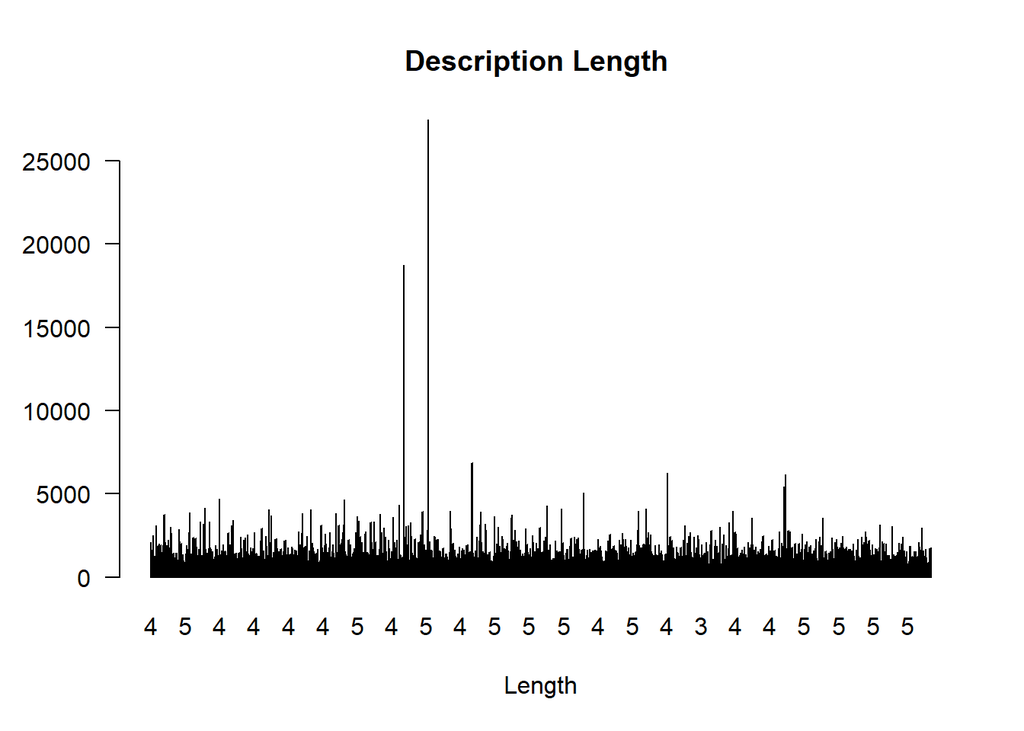

```r
datalist <- data_goodread[c(3, 4)]
dataFrame <- datalist %>%
  as_tibble()
dataFrame <- na.omit(dataFrame)
coul <- brewer.pal(5, "Set2")
barplot(dataFrame$desc_len,
        main = "Description Length ",
        ylab = "",
        xlab = "Length",
        names.arg = dataFrame$rating_category,
        col = coul,
        width=c(1),
        las=1,
        horiz = FALSE
)
```

## 1.7 Create a random stratified training and test split (70/30 split). Verify the correct proportions of the splitted data sets by creating proportion table.

```r
set.seed(123)
data_split = sample.split(data_goodread$rating_category, SplitRatio = .7)
train_data = subset(data_goodread, data_split == TRUE)
test_data  = subset(data_goodread, data_split == FALSE)

# check the proportions
prop.table(table(train_data$rating_category))
```

```
##
##            1            2            3            4            5
## 0.0002901073 0.0029010734 0.0252393386 0.5947200464 0.3768494343
```

```r
prop.table(table(train_data$rating_category))
```

```
##
##            1            2            3            4            5
## 0.0002901073 0.0029010734 0.0252393386 0.5947200464 0.3768494343
```

## 1.8 Tokenize the descriptions with help of the quanteda package and illustrate the effect of each action by showing the content of some of the reviews in the training data set

```r
#Creating corpus for train data:
corpus_train <- VCorpus(VectorSource(train_data$desc))
as.character(corpus_train[[2]])
```

```
## [1] "Popularized by Michael Pollan in his best-selling ,In Defense of Food,, Gyorgy Scrinis's concept of nutritionism refers to the reductive understanding of nutrients as the key indicators of healthy food--an approach that has dominated nutrition science, dietary advice, and food marketing. Scr…
```

Before we proceed on with the text mining analysis, we have to create corpus from the string of texts. Corpus is set of documents.  
There are two types of Corpus,  
1. Permanent corpus - PCorpus  
2. Volatile corpus - VCorpus.

#Clean the corpus with the help of the tm map() function - transformer()

```r
#1. Casing
corpus_train <- tm_map(corpus_train, content_transformer(tolower))
as.character(corpus_train[[2]])
```

```
## [1] "popularized by michael pollan in his best-selling ,in defense of food,, gyorgy scrinis's concept of nutritionism refers to the reductive understanding of nutrients as the key indicators of healthy food--an approach that has dominated nutrition science, dietary advice, and food marketing. scr…
```

The text is coverted with lower cases.

```r
#2. Puntucation
corpus_train <- tm_map(corpus_train, removePunctuation)
as.character(corpus_train[[2]])
```

```
## [1] "popularized by michael pollan in his bestselling in defense of food gyorgy scriniss concept of nutritionism refers to the reductive understanding of nutrients as the key indicators of healthy foodan approach that has dominated nutrition science dietary advice and food marketing scrinis argue…
```

Punctuations are removed from the texts

```r
#3. Number
corpus_train <- tm_map(corpus_train, removeNumbers)
as.character(corpus_train[[2]])
```

```
## [1] "popularized by michael pollan in his bestselling in defense of food gyorgy scriniss concept of nutritionism refers to the reductive understanding of nutrients as the key indicators of healthy foodan approach that has dominated nutrition science dietary advice and food marketing scrinis argue…
```

Number are removed from the texts

```r
#4. Stop words
corpus_train <- tm_map(corpus_train, removeWords, stopwords("english"))
as.character(corpus_train[[2]])
```

```
## [1] "popularized  michael pollan   bestselling  defense  food gyorgy scriniss concept  nutritionism refers   reductive understanding  nutrients   key indicators  healthy foodan approach   dominated nutrition science dietary advice  food marketing scrinis argues  ideology  narrowed    cases distor…
```

Commonly used words and less informative words are removed from the texts

```r
#6. Reducing root words
corpus_train <- tm_map(corpus_train, stemDocument)
as.character(corpus_train[[2]])
```

```
## [1] "popular michael pollan bestsel defens food gyorgi scriniss concept nutrition refer reduct understand nutrient key indic healthi foodan approach domin nutrit scienc dietari advic food market scrini argu ideolog narrow case distort appreci food qualiti even high process food may perceiv health…
```

Root words are redcued from the texts

```r
#7. Removed white space
corpus_train <- tm_map(corpus_train, stripWhitespace)
as.character(corpus_train[[2]])
```

```
## [1] "popular michael pollan bestsel defens food gyorgi scriniss concept nutrition refer reduct understand nutrient key indic healthi foodan approach domin nutrit scienc dietari advic food market scrini argu ideolog narrow case distort appreci food qualiti even high process food may perceiv health…
```

Any white speace in the text is removed

## 1.9 Create a bag-of-words model and add bi-grams to the normal feature matrix.

```r
dtm_train <- DocumentTermMatrix(corpus_train)
dtm_train
```

```
## <<DocumentTermMatrix (documents: 3447, terms: 41759)>>
## Non-/sparse entries: 218178/143725095
## Sparsity           : 100%
## Maximal term length: 2598
## Weighting          : term frequency (tf)
```

Now the train data is convereted into bag of words where each text is coverted as a feature .

```r
inspect(dtm_train)
```

```
## <<DocumentTermMatrix (documents: 3447, terms: 41759)>>
## Non-/sparse entries: 218178/143725095
## Sparsity           : 100%
## Maximal term length: 2598
## Weighting          : term frequency (tf)
## Sample             :
##       Terms
## Docs   book can life love new one stori time work world
##   1025    0   0    0    0   0   0     0    0    0     0
##   1339    4   8    4    0   2   0     0    3    4     1
##   1478    0   0    0    0   0   1     0    1    1     0
##   1618    6   2    2    0   3   1     0    1    0     1
##   175     1   0    3    2   7   1     2    3    3     0
##   1758    0   0    0    0   0   5     0    2    0     0
##   2186    0   0    0    0   0   0     0    0    0     0
##   2584    0   0    0    0   2   0     1    2    1     1
##   676     0   1    1    0   4   1     4    1    3     0
##   711     0   1    0    0   0   0     0    0    2     3
```

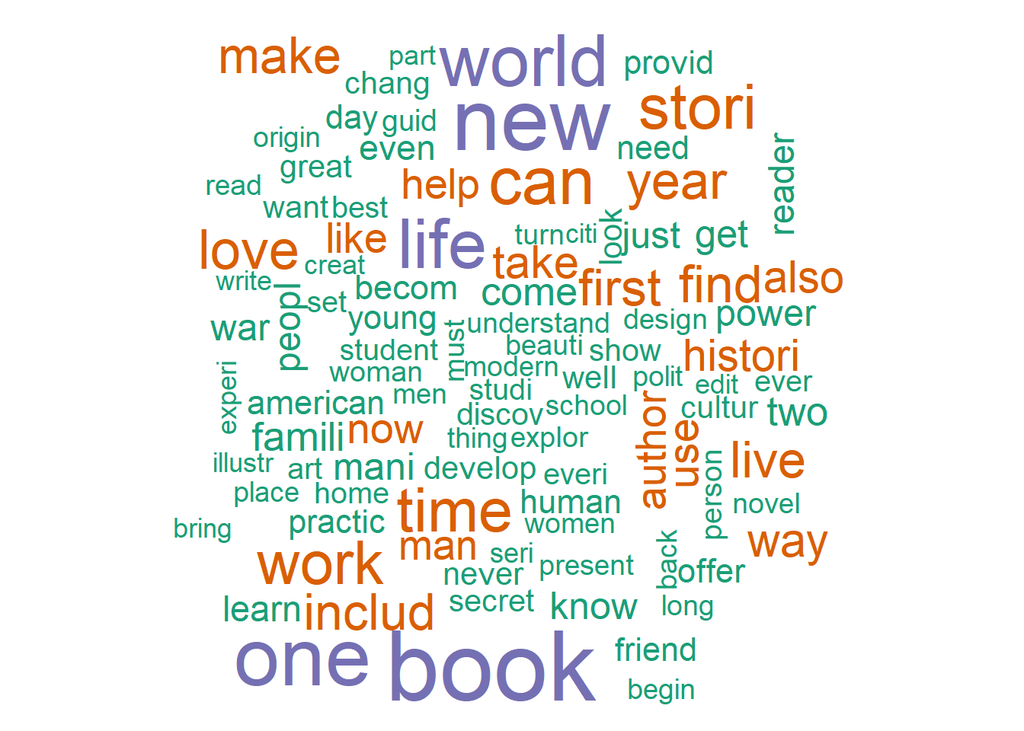

```r
#Drawing a simple word cloud of the most frequent repeated words
freq_term_cloud = data.frame(sort(colSums(as.matrix(dtm_train)), decreasing=TRUE))
wordcloud(rownames(freq_term_cloud), freq_term_cloud[,1], max.words=100, colors=brewer.pal(1, "Dark2"))
```

This graphs displays the frequently repeated words. To illustrate New, book, life and one which are most repeated.

## 1.10 Build a function for relative term frequency (TF) and another one to calculate the inverse document frequency (IDF). Use both functions to create a function which calculated the TF-IDF.Use these three functions on the feature matrix separately to create a term-document frequency matrix.

```r
dtm_train <- DocumentTermMatrix(corpus_train, control = list(weighting = weightTfIdf))
```